# A1. Monte Carlo Approximation von $\pi$

In dieser Aufgabe schätzen wir die Kreiszahl $\pi$ durch zufällig gezogene Punkte innerhalb des Quadrats $[-1, 1]^2$.

Die Wahrscheinlichkeit, dass ein Punkt innerhalb des Einheitskreises liegt, entspricht dem Verhältnis der Flächen:

$$\mathbb{P}(x^2 + y^2 \leq 1) = \frac{\pi r^2}{4 r^2} = \frac{\pi}{4}$$

Da $z_i = 4 \cdot \mathbf{1}(x_i^2 + y_i^2 \leq 1)$, ist dies ein Bernoulli-Kette mit Erwartungswert:

$$\mathbb{E}[z_i] = 4 \cdot \frac{\pi}{4} = \pi$$

Somit ist der Stichprobenmittelwert $\hat{\pi} = \frac{1}{n} \sum z_i$ eine Schätzung von $\pi$.

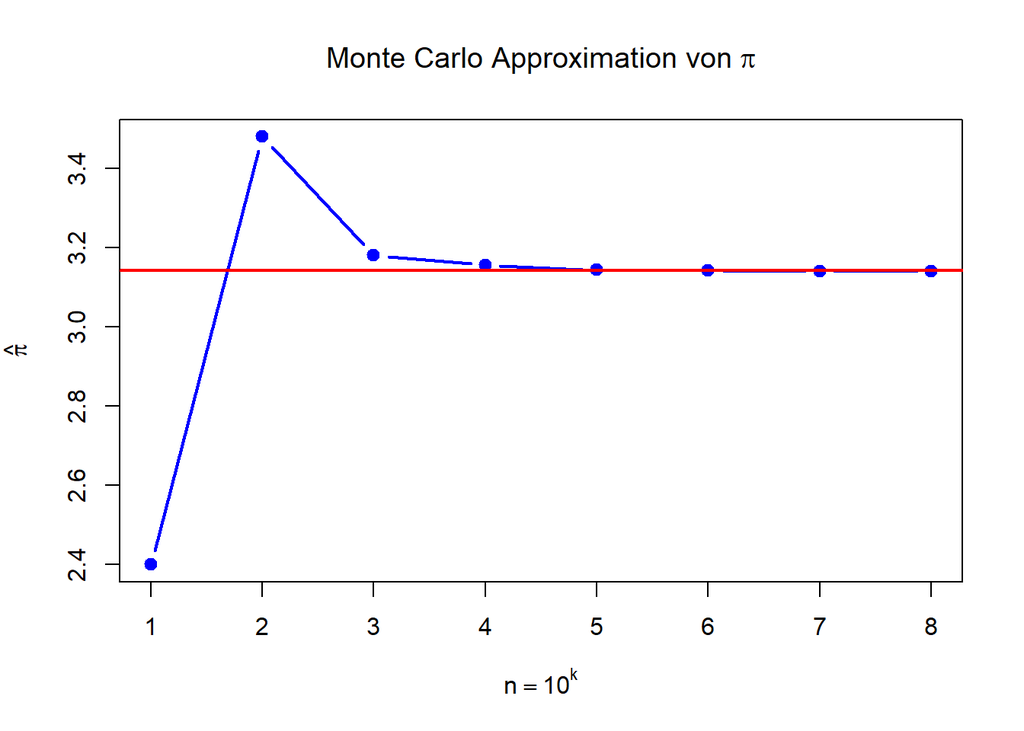

```r
set.seed(123)  # Seed setzen für Reproduzierbarkeit
k = 8
alpha <- 0.05 # 95% Sicherheit

df <- data.frame(
  k = 1:k,
  n = 10^(1:k)
)

df$mean <- sapply(df$n, function(n) {
  x <- runif(n, -1, 1) #  n gleichverteilte Zufallszahlen zwischen -1 und 1 erzeugen
  y <- runif(n, -1, 1)
  mean(4 * (x^2 + y^2 <= 1))
})

df$var <- sapply(df$n, function(n) {
  x <- runif(n, -1, 1)
  y <- runif(n, -1, 1)
  var(4 * (x^2 + y^2 <= 1))
})

df$error <- sqrt(df$var / (alpha * df$n)) # Fehlerabschätzung basierend auf Tschebyscheff-Ungleichung

# Plot
plot(df$k, df$mean, type = "b", lwd = 2, pch = 19, col = "blue",
     xlab = expression(n == 10^k),
     ylab = expression(hat(pi)),
     main = expression("Monte Carlo Approximation von"~pi))
abline(h = pi, col = "red", lwd = 2)
```

```r
df
##   k     n     mean      var        error
## 1 1 1e+01 2.400000 1.600000 1.7888543820
## 2 2 1e+02 3.480000 3.258182 0.8072399666
## 3 3 1e+03 3.180000 2.619644 0.2288948948
## 4 4 1e+04 3.156400 2.698845 0.0734689764
## 5 5 1e+05 3.143560 2.687353 0.0231834103
## 6 6 1e+06 3.142612 2.698049 0.0073458133
## 7 7 1e+07 3.141214 2.698435 0.0023231165
## 8 8 1e+08 3.141456 2.696273 0.0007343396
```

- Interpretation: Die Genauigkeit der Monte Carlo-Approximation von $\pi$ steigt mit wachsender Stichprobengröße $n$, während die Varianz der Schätzungen entsprechend sinkt (Gesetz der großen Zahlen).

# A2. Monte Carlo Integration

In dieser Übung soll der Wert $1.96$ als $0.975-Quantil$ der Standardnormalverteilung mit Hilfe von Monte Carlo Integration überprüft werden.

## a. n gleichverteilte Zufallszahlen

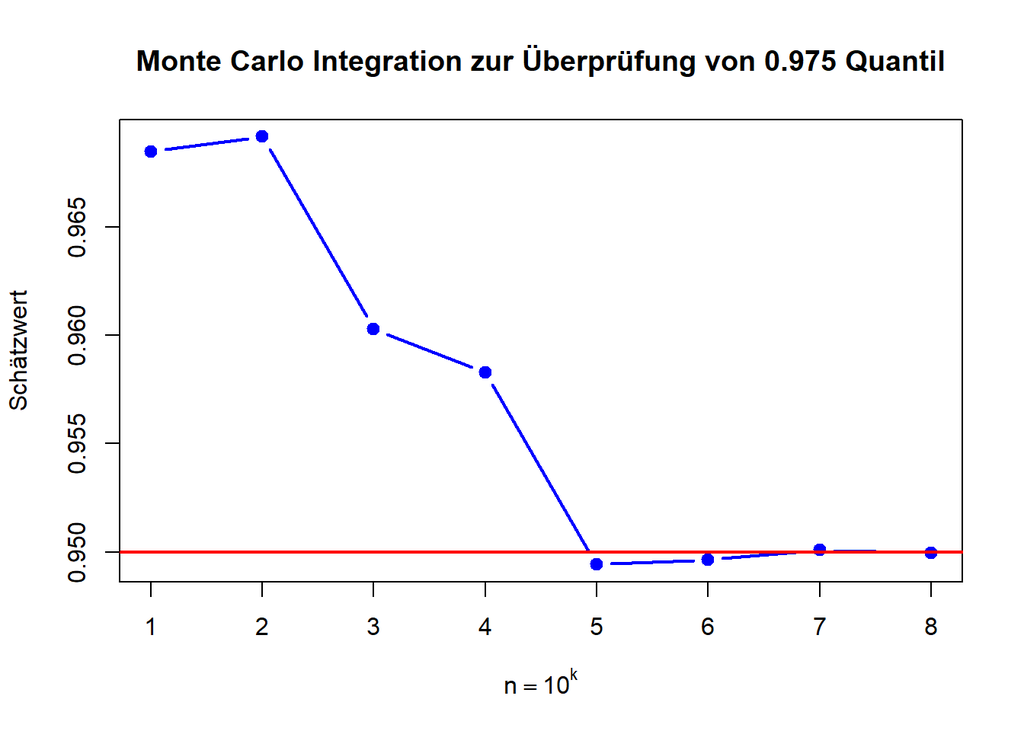

```r
set.seed(123)  # Seed setzen für Reproduzierbarkeit
k = 8
alpha <- 0.05
Q <- 1.96 # 0.975-Quantil der Standardnormalverteilung

df <- data.frame(
  k = 1:k,
  n = 10^(1:k)
)

df$mean <- sapply(df$n, function(n) {
  x <- runif(n, -Q, Q) # n gleichverteilte Zufallsvariablen zwischen -Q und Q
  mean(2 * Q * dnorm(x))
})

df$var <- sapply(df$n, function(n) {
  x <- runif(n, -Q, Q)
  var(2 * Q * dnorm(x))
})

df$error <- sqrt(df$var / (alpha * df$n)) # Fehlerabschätzung basierend auf Tschebyscheff-Ungleichung

# Plot
plot(df$k, df$mean, type = "b", lwd = 2, pch = 19, col = "blue",
     xlab = expression(n == 10^k),
     ylab = "Schätzwert",
     main = "Monte Carlo Integration zur Überprüfung von 0.975 Quantil")
abline(h = 0.95, col = "red", lwd = 2)
```

```r
df
##   k     n      mean       var        error
## 1 1 1e+01 0.9684838 0.2404018 0.6934000096
## 2 2 1e+02 0.9691602 0.1752135 0.1871969795
## 3 3 1e+03 0.9602923 0.1940901 0.0623041169
## 4 4 1e+04 0.9582903 0.1983122 0.0199154330
## 5 5 1e+05 0.9494218 0.1965286 0.0062694272
## 6 6 1e+06 0.9496388 0.1971466 0.0019856818
## 7 7 1e+07 0.9500912 0.1971818 0.0006279837
## 8 8 1e+08 0.9499596 0.1971159 0.0001985527
```

- Interpretation: Mit zunehmender Stichprobengröße nn wird die Monte Carlo Schätzung des $0.975-Quantils$ der Standardnormalverteilung zunehmend genauer und stabilisiert sich sehr nah am theoretischen Wert von 0.95 (Gesetz der großen Zahlen).

## b. Die Verteilung der Schätzer

Führe für die Werte $n = 10^5$, $n = 10^6$ und $n = 10^7$ jeweils $200$ Approximationen durch und stelle die Verteilung der Schätzer für $p = 0.95$ in einer gemeinsamen Abbildung dar. Interpretiere das Ergebnis.

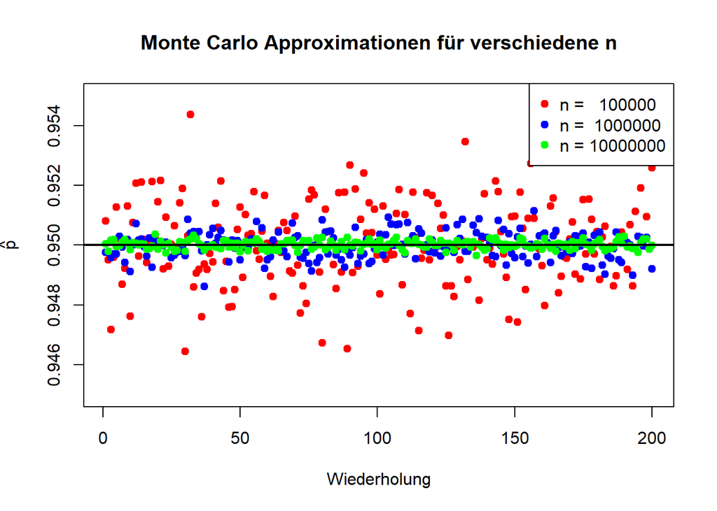

```r
set.seed(123)  # Seed setzen für Reproduzierbarkeit

N <- 200 # Anzahl der Wiederholungen
n_values <- c(10^5, 10^6, 10^7)
Q <- 1.96
y_lim <- c(0.945, 0.955)
farben <- c("red", "blue", "green")

results <- list()
for (n in n_values) {
  z_mean <- replicate(N, {
    x <- runif(n, -Q, Q) # n gleichverteilte Zufallsvariablen zwischen -Q und Q
    mean(2 * Q * dnorm(x))
  })
  results[[as.character(n)]] <- z_mean
}

# Plot
plot(1:N, results[[1]], col = farben[1], pch = 19, ylim = y_lim,
     xlab = "Wiederholung", ylab = expression(hat(p)),
     main = "Monte Carlo Approximationen für verschiedene n")
for (i in 2:length(n_values)) {
  points(1:N, results[[i]], col = farben[i], pch = 19)
}
abline(h = 0.95, col = "black", lwd = 2)
legend('topright', legend = paste("n =", format(n_values, scientific = FALSE)),
       col = farben, pch = 19)
```

- Interpretation: Mit zunehmender Stichprobengröße $n$ verringert sich die Varianz der Schätzungen signifikant.  
Bei $n = 10^7$ (grün) ist die Approximation extrem präzise und praktisch perfekt auf $0{,}95$ zentriert.  
Die grafische Darstellung bestätigt eindrucksvoll die Konvergenzeigenschaften der Monte Carlo Integration und das Gesetz der großen Zahlen.

# A3. Berechnen einer Fläche

In dieser Übung soll eine Fläche mithilfe von Monte-Carlo-Integration berechnet werden.  
Als umgebendes Rechteck wählen wir $[-7, 7] \times [-4, 4]$, die Fläche $A$ ist durch folgende Ungleichung definiert:

$$\frac{x^2}{49} + \frac{y^2}{9} - 1 \leq 0$$

Erzeuge $n = 10^5$ Tupel $(x_i, y_i)$ für $i = 1, \dotsc, n$ mit $x_i \sim \mathcal{U}([-7, 7])$ und $y_i \sim \mathcal{U}([-4, 4])$ und bilde hieraus die Bernoulli-Variable $z_i = \mathbf{1}_A(x_i, y_i)$.

## a. Graphische Darstellung der Fläche A

Stelle die Fläche A anhand der Punkte, die in A liegen, graphisch dar. Wenn die Ungleichungen richtig umgesetzt wurde, sollte Dir die Fläche bekannt vorkommen.

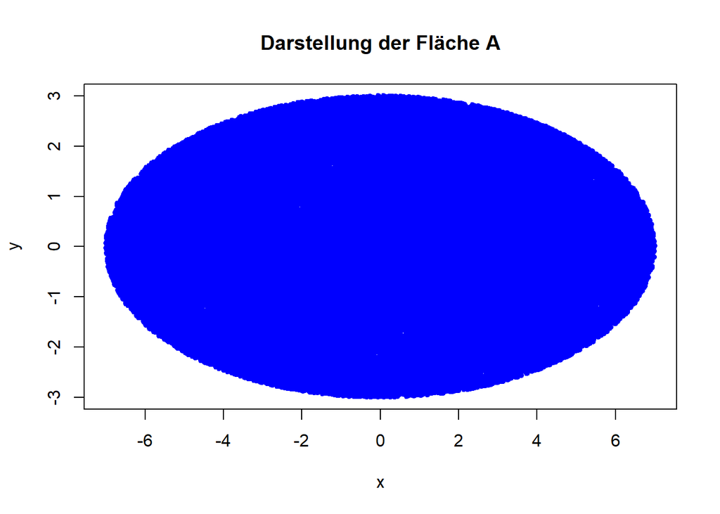

```r
set.seed(123)  # Seed setzen für Reproduzierbarkeit

n <- 10^5
x <- runif(n, min = -7, max = 7)
y <- runif(n, min = -4, max = 4)

# Berechne die Funktion f(x, y) für jedes Tupel
f <- x^2 / 49 + y^2 / 9 - 1

# Bestimme die Punkte, die in A liegen
indices_A <- which(f <= 0)
x_A <- x[indices_A]
y_A <- y[indices_A]

# Plot der Punkte in A
plot(x_A, y_A, pch = 20, col = "blue",
     main = "Darstellung der Fläche A",
     xlab = "x",
     ylab = "y")
```

## b. Naherungsweise der Flächeninhalt

```r
A <- (7*4) * (length(indices_A)/n)
print(paste("Der Flächeninhalt A beträgt näherungsweise:", A))
```

```
## [1] "Der Flächeninhalt A beträgt näherungsweise: 16.51384"
```